# Trabajo Regresión lineal: predicción de la nota media de los alumnos grado de la ETSIT UPCT. Segunda parte.

Nombre: Jairo

Apellidos: Peña Iglesias

```r
## cargamos los paquetes dplyr, ggplot2
library("dplyr") # Para manipular data.frames
library("ggplot2") # Para hacer gráficas
```

> En este trabajo, usamos datos asociados a todos los alumnos de Grado en Ingeniería Telemática y Grado en Ingeniería de Sistemas de Telecomunicación de la UPCT, que hayan superado 120 ECTS, que provengan de la Región de Murcia y que se hayan examinado de Física y Matemáticas_II en la Prueba de Acceso a la Universidad (PAU).

# Objetivo:

Nuestro objetivo es estudiar la posibilidad de predecir la nota media a partir de algunos datos en el ingreso del estudiante (calificación y decil PAU, así como de Física y Matemáticas II) y de sus resultados en algunas de las asignaturas más exigentes de la titulación:

1. Fundamentos de programación.
2. Sistemas y circuitos.
3. Teoría de la comunicación.

# Segundo paso: conjunto completo

Vamos a trabajar con el conjunto completo. El fichero que contiene los datos es notamediagradosETSIT-completo.csv que se puede descargar del Aula Virtual y guardar en la carpeta data del directorio asociado a nuestro nuevo proyecto.

Cargar los datos en un dataframe llamado **GradosTeleco**

```r
GradosTeleco <- read.table(file = "data/notamediagradosETSIT-completo.csv",
                           header = TRUE, sep = ";",
                           dec = ".",
                           stringsAsFactors = FALSE)
```

Tenemos las variables siguientes:

- notamedia: La nota media está calculada con las calificaciones de cada asignatura en una escala que va de 1 a 4 (1 es “Aprobado”, 2 “Notable”, 3 “Sobresaliente”, 4 “Matrícula de Honor”)
- PAU_CALIFICACION_NOTA_MATERIA y PAU_CALIFICACION_NOTA_MATERIA_DECIL: nota final (sobre 10) y DECIL del alumno en su año de PAU, respecto a todos los alumnos presentados a PAU ese año.
- “FISICA_NOTA_MATERIA” y “FISICA_NOTA_MATERIA_decil” nota y decil en la materia de Física en la PAU
- “MATEMATICAS_II_NOTA_MATERIA” y “MATEMATICAS_II_NOTA_MATERIA_DECIL” nota y decil en la materia de MATEMATICAS_II en la PAU.

Además, para cada una de las asignaturas seleccionadas de la UPCT, tenemos tres variables:

- ****_NOTA: la nota sobre 10 obtenida en la asignatura
- ****_CONVOCS_PRESENTADAS_ACUMULA: el número de convocatorias presentadas para superar la asignatura
- *****CONVOCS_HASTA_1RA_VEZ* el número de convocatorias que ha necesitado para presentarse por primera vez a la asignatura.

Nota: en el caso de asignaturas reconocidas, estas dos últimas variables valen 0.

## Construcción de un conjunto de entrenamiento y otro conjunto de test…

Para poder comprobar la posibilidad de predecir la nota media a partir de las variables que nos interesan, vamos a construir un conjunto de entrenamiento (Learning set) y otro de test: - Con el conjunto de entrenamiento, llevaremos a cabo el ajuste de regresión lineal obteniendo la relación
$$notamedia=\theta_0+\theta_1x_1+\ldots\theta_k x_k,$$
donde $x_1,\ x_2,\ldots,x_k$ son las características que consideraremos. - Con el conjunto de test, aplicaremos el modelo ajustado obtenido con el conjunto de entrenamiento para predecir la nota media y veremos qué error cometemos, puesto que en realidad conocemos cuál fue la nota media de los alumnos del conjunto test.

### Selección del conjunto training

Usando la instrucción **sample** (ver ayuda), podemos escoger entre las posiciones de los individudos del conjunto GradosTeleco, los que escogeremos para el conjunto de entrenamiento. Escogeremos al azar 70% de los individuos totales (es decir 70 alumnos aprox.).

```r
set.seed(seed = 1) # fijamos la semilla del algoritmo aleatorio para
## poder comparar  nuestros resultados con los de compañeros
## completar aquí: para obtener el vector training.posiciones

rows <- c(1 : nrow(GradosTeleco))
training.posiciones <- sample(rows, nrow(GradosTeleco)*0.7)

## completar aquí para construir el subconjunto GradosTeleco.training que
## corresponda a los GradosTeleco escogidos

GradosTeleco.training <- GradosTeleco[training.posiciones,]
```

### Selección del conjunto test.

Debemos ahora construir el conjunto test que consistirá en los GradosTeleco que no han sido seleccionado para el conjunto training. Para ello, usaremos primero el operador lógico **%in%** que permite comprobar la pertenencia a un vector de valores.

```r
## nada que completar, pero sí podéis comprobar que entendéis el código:
test.posiciones <- which(! (row.names(GradosTeleco) %in% training.posiciones)) #cogemos los valores que NO pertenecen al conjunto de prueba (training.posiciones)

## hemos usado la negación lógica que es !,
## (es decir !FALSE es TRUE, y !TRUE es FALSE)

## **%in%** operador lógico que permite comprobar la pertenencia a un vector de valores
```

Ahora podéis crear el data.frame GradosTeleco.test, subconjunto del dataframe GradosTeleco, que contenga los GradosTeleco escogidos para formar parte del conjunto test.

```r
## Construimos el vector GradosTeleco.test
GradosTeleco.test <- GradosTeleco[test.posiciones,] #recuerda que termina en coma para que cojamos toda la fila
```

## Predicción con solamente las variables PAU.

Para ir más rápido, usaremos las soluciones analíticas a las ecuaciones normales para la regresión lineal tal como nos las da la instrucción **lm** y no usaremos el algoritmo del gradiente.

### Ajuste con lm

Crear un objeto **training.lm.PAU** que sea el resultado de llevar a cabo, con el conjunto GradosTeleco.training el ajuste lineal para predecir la nota media en función de las variables PAU del conjunto.

** NOTA ** Un pequeño truco para escribir las fórmulas más rapidamente con todas esas variables: se puede usar en la consola paste con el argumento collapse

```r
## nada que completar aquí
paste(names(GradosTeleco)[-1],collapse=" + ")
```

```
## [1] "ALU_EXP_ID + notamedia + PAU_CALIFICACION_NOTA_MATERIA + PAU_CALIFICACION_NOTA_MATERIA_DECIL + FISICA_NOTA_MATERIA + FISICA_NOTA_MATERIA_DECIL + MATEMATICAS_II_NOTA_MATERIA + MATEMATICAS_II_NOTA_MATERIA_DECIL + FUNDAMENTOS_DE_PROGRAMACION_NOTA + FUNDAMENTOS_DE_PROGRAMACION_CONVOCS_PRESENTADA…
```

Así obtenemos una larga cadena de caractéres que podemos aprovechar para copiar y pegar para facilitar la redacción de la fórmula en lm…

```r
## Completar aquí para obtener el objeto training.lm.PAU
training.lm.PAU <- lm(data = GradosTeleco.training, notamedia ~ PAU_CALIFICACION_NOTA_MATERIA + PAU_CALIFICACION_NOTA_MATERIA_DECIL + FISICA_NOTA_MATERIA + FISICA_NOTA_MATERIA_DECIL + MATEMATICAS_II_NOTA_MATERIA + MATEMATICAS_II_NOTA_MATERIA_DECIL)
##Variable = notamedia
##Característica = asignaturas de la PAU
##he tomado los valores de la PAU que me proporcionan una nota media
```

### Predicción sobre el conjunto test.

Debemos ahora usar el comando **predict** que se aplica a un objeto resultado del ajuste con lm, y que admite como argumento un data.frame para el cual queremos hacer las predicciones (en nuestro caso GradosTeleco.test).

Crear un objeto llamado test.predict.PAU, que contenga el resultado de las predicciones para los individuos del conjunto de test, usando el ajuste de training.lm.PAU

```r
## Creamos el data.frame test.predict.PAU
test.predict.PAU <- predict(training.lm.PAU, GradosTeleco.test)
```

Si no os habéis equivocado tenéis que obtener para los seis primeros valores: 3 8 15 18 26 30

1.878 1.745 1.723 1.801 1.678 1.362

### Comprobación de la calidad de la predicción para el conjunto test.

Cremos ahora el vector errores.predict.PAU que contenga los errores que hemos cometido en la predicción de las notas medias para el conjunto test, si usamos el ajuste solamente con las características PAU de los alumnos…

```r
## Completar aquí para obtener el vector errores.predict.PAU
errores.predict.PAU <- GradosTeleco.test$notamedia - test.predict.PAU
##al valor de la notamedia de los datos GradoTeleco le resto mi prediccion con los datos que supuse que obtendria tras analizar solo la PAU
```

Para poder compararlo más adelante con otros ajustes (una vez que introduzcamos más características para mejor la predicción…), vamos a meter estos errores en un dataframe.

```r
### Nada que completar, pero sí comprobar que entendéis el código
errores <- data.frame(caracteristicas = "Sólo PAU",
                      errores = errores.predict.PAU)
```

Para comprobar la calidad de nuestra predicción, debemos ver si los errores son grandes. Podemos empezar por realizar una gráfica de densidad para visualizar su distribución (con ggplot, usando geom_density, rellenando con un color azul con transparencia 0.5)

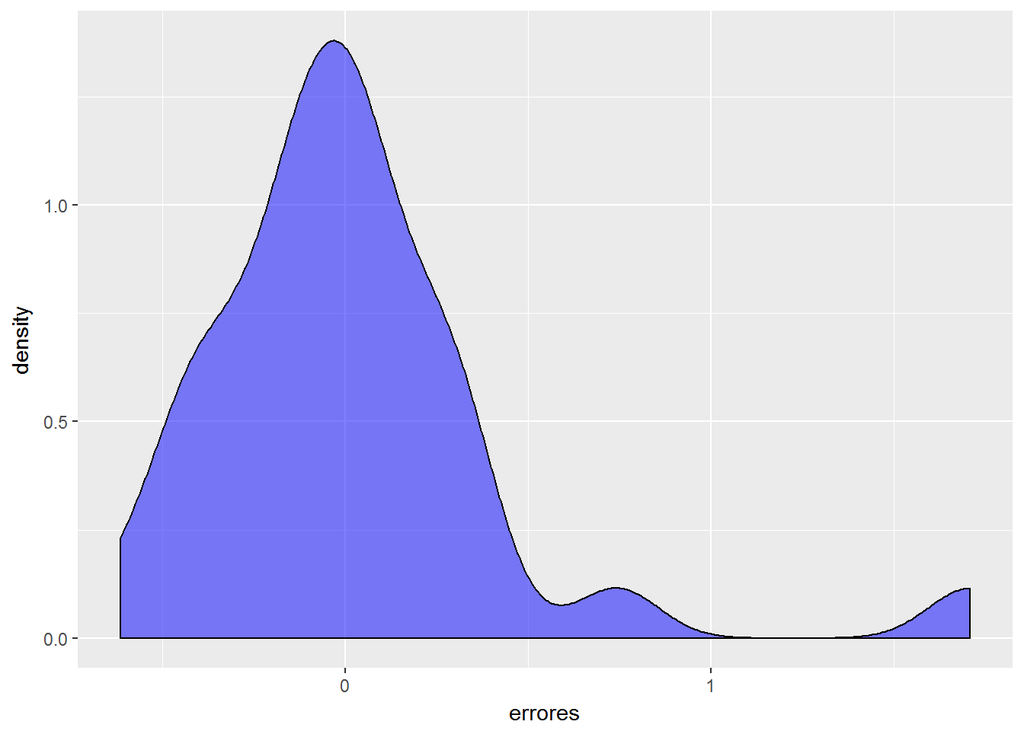

```r
### Completar aquí, usando ggplot con geom_density
plot <- errores  %>%
        ggplot(aes(x = errores))
plot + geom_density(fill = "blue", alpha = 0.5)
```

Para obtener indicadores numéricos de la calidad de la predicción, calcularemos tres cosas:

1. El error cuadrático media de la predicción: es decir la media de los errores elevados al cuadrado.
2. El porcentaje de GradosTeleco en el conjunto test para los cuáles el valor absoluto del error es menor que un cuarto de punto..
3. El porcentaje de GradosTeleco en el conjunto test para los cuáles el valor absoluto del error es menor que una décima de punto.

Vamos a crear con dplyr un dataframe que llamaremos **resumenerrores**, que sea el resultado de agrupar **errores** (que ya tenemos definido) por la columna **caracteristicas* y resumir para obtener los tres indicadores arriba definidos.

```r
## Completar aquí para obtener resumenerrores
resumenerrores <- errores %>%
                  group_by(caracteristicas) %>%
                  summarise(error_cuadratico = mean(errores^2, na.rm = TRUE), ##1
                         p0.25 = sum(abs(errores) < 0.25, na.rm =
                                       TRUE) / length(errores) * 100, ##2
                         p0.1 = sum(abs(errores) < 0.1, na.rm =
                                      TRUE) / length(errores) * 100) ##3
```

## Predicción con las variables PAU y las variables de las asignaturas seleccionadas de primer curso

Vamos ahora a añadir como características las variables asociadas a las asignaturas " Fundamentos de programación" y “Sistemas y circuitos” que son asignaturas de primer curso respectivamente.

Seguiremos los mismos pasos que para el ajuste con solamente variables PAU.

### Ajuste con lm

Crear un objeto **training.lm.PAU.primercurso** que sea el resultado de llevar a cabo, con el conjunto GradosTeleco.training el ajuste lineal para predecir la nota media en función de las variables PAU del conjunto.

```r
## Completar aquí para obtener training.lm.PAU.primeroscursos
training.lm.PAU.primeroscursos <- lm(data = GradosTeleco.training, notamedia ~ PAU_CALIFICACION_NOTA_MATERIA + PAU_CALIFICACION_NOTA_MATERIA_DECIL + FISICA_NOTA_MATERIA + FISICA_NOTA_MATERIA_DECIL + MATEMATICAS_II_NOTA_MATERIA + MATEMATICAS_II_NOTA_MATERIA_DECIL + FUNDAMENTOS_DE_PROGRAMACION_NOTA + FUNDAMENTOS_DE_PROGRAMACION_CONVOCS_PRESENTADAS_ACUMULA + FUNDAMENTOS_DE_PROGRAMACION_CONVOCS_HASTA_1RA_VEZ_ACUMULA + SISTEMAS_Y_CIRCUITOS_NOTA + SISTEMAS_Y_CIRCUITOS_CONVOCS_PRESENTADAS_ACUMULA + SISTEMAS_Y_CIRCUITOS_CONVOCS_HASTA_1RA_VEZ_ACUMULA)

summary(training.lm.PAU.primeroscursos)
```

```
##
## Call:
## lm(formula = notamedia ~ PAU_CALIFICACION_NOTA_MATERIA + PAU_CALIFICACION_NOTA_MATERIA_DECIL +
##     FISICA_NOTA_MATERIA + FISICA_NOTA_MATERIA_DECIL + MATEMATICAS_II_NOTA_MATERIA +
##     MATEMATICAS_II_NOTA_MATERIA_DECIL + FUNDAMENTOS_DE_PROGRAMACION_NOTA +
##     FUNDAMENTOS_DE_PROGRAMACION_CONVOCS_PRESENTADAS_ACUMULA +
##     FUNDAMENTOS_DE_PROGRAMACION_CONVOCS_HASTA_1RA_VEZ_ACUMULA +
##     SISTEMAS_Y_CIRCUITOS_NOTA + SISTEMAS_Y_CIRCUITOS_CONVOCS_PRESENTADAS_ACUMULA +
##     SISTEMAS_Y_CIRCUITOS_CONVOCS_HASTA_1RA_VEZ_ACUMULA, data = GradosTeleco.training)
##
## Residuals:
##      Min       1Q   Median       3Q      Max
## -0.48085 -0.16601 -0.03528  0.16758  0.62207
##
## Coefficients:
##                                                            Estimate
## (Intercept)                                               -1.409570
## PAU_CALIFICACION_NOTA_MATERIA                              0.345805
## PAU_CALIFICACION_NOTA_MATERIA_DECIL                       -0.077639
## FISICA_NOTA_MATERIA                                       -0.102073
## FISICA_NOTA_MATERIA_DECIL                                  0.075124
## MATEMATICAS_II_NOTA_MATERIA                                0.002515
## MATEMATICAS_II_NOTA_MATERIA_DECIL                          0.014138
## FUNDAMENTOS_DE_PROGRAMACION_NOTA                           0.073213
## FUNDAMENTOS_DE_PROGRAMACION_CONVOCS_PRESENTADAS_ACUMULA   -0.020246
## FUNDAMENTOS_DE_PROGRAMACION_CONVOCS_HASTA_1RA_VEZ_ACUMULA  0.011129
## SISTEMAS_Y_CIRCUITOS_NOTA                                  0.093234
## SISTEMAS_Y_CIRCUITOS_CONVOCS_PRESENTADAS_ACUMULA          -0.020152
## SISTEMAS_Y_CIRCUITOS_CONVOCS_HASTA_1RA_VEZ_ACUMULA        -0.089396
##                                                           Std. Error
## (Intercept)                                                 0.473933
## PAU_CALIFICACION_NOTA_MATERIA                               0.115694
## PAU_CALIFICACION_NOTA_MATERIA_DECIL                         0.049149
## FISICA_NOTA_MATERIA                                         0.067318
## FISICA_NOTA_MATERIA_DECIL                                   0.054966
## MATEMATICAS_II_NOTA_MATERIA                                 0.044553
## MATEMATICAS_II_NOTA_MATERIA_DECIL                           0.038518
## FUNDAMENTOS_DE_PROGRAMACION_NOTA                            0.025037
## FUNDAMENTOS_DE_PROGRAMACION_CONVOCS_PRESENTADAS_ACUMULA     0.033810
## FUNDAMENTOS_DE_PROGRAMACION_CONVOCS_HASTA_1RA_VEZ_ACUMULA   0.059507
```

[output cut: 23 more lines]

```
## MATEMATICAS_II_NOTA_MATERIA
## MATEMATICAS_II_NOTA_MATERIA_DECIL
## FUNDAMENTOS_DE_PROGRAMACION_NOTA                          **
## FUNDAMENTOS_DE_PROGRAMACION_CONVOCS_PRESENTADAS_ACUMULA
## FUNDAMENTOS_DE_PROGRAMACION_CONVOCS_HASTA_1RA_VEZ_ACUMULA
## SISTEMAS_Y_CIRCUITOS_NOTA                                 **
## SISTEMAS_Y_CIRCUITOS_CONVOCS_PRESENTADAS_ACUMULA
## SISTEMAS_Y_CIRCUITOS_CONVOCS_HASTA_1RA_VEZ_ACUMULA
## ---
## Signif. codes:  0 '***' 0.001 '**' 0.01 '*' 0.05 '.' 0.1 ' ' 1
##
## Residual standard error: 0.2668 on 52 degrees of freedom
##   (3 observations deleted due to missingness)
## Multiple R-squared:  0.6365, Adjusted R-squared:  0.5526
## F-statistic: 7.587 on 12 and 52 DF,  p-value: 7.421e-08
```

```r
##Variable = notamedia
##Característica = asignaturas de la carrera
##he tomado los valores de las notas de la PAU + las notas de las asignaturas de la carrera que me proporcionan una nota media
```

### Predicción de la nota media para el conjunto test

Crear un objeto llamado test.predict.PAU.primeroscursos, que contenga el resultado de las predicciones para los individuos del conjunto de test, usando el ajuste de training.lm.PAU.primeroscursos

```r
## Completar aquí par crear test.predict.PAU.primeros cursos
test.predict.PAU.primeroscursos <- predict(training.lm.PAU.primeroscursos, GradosTeleco.test)
```

### Comprobación de la calidad de la predicción para el conjunto test.

Cremos ahora el vector errores.predict.PAU.primeroscursos que contenga los errores que hemos cometido en la predicción de las notas medias para el conjunto test, si usamos el nuevo ajuste.

```r
## Completar aquí para obtener el vector errores.predict.PAU.primeroscursos
errores.predict.PAU.primeroscursos <- GradosTeleco.test$notamedia - test.predict.PAU.primeroscursos
```

Vamos ahora a añadir estos errores al dataframe errores que ya contenía los errores para el ajuste con solamente las características PAU.

```r
### Nada que completar, pero sí comprobar que entendéis el código
errores <- rbind(errores,
                 data.frame(caracteristicas = "PAU y primer curso",
                            errores = errores.predict.PAU.primeroscursos))
```

Realizamos ahora una gráfica de densidad para visualizar la distribución de los errores cometidos en la predicción, pero distinguiendo entre los dos ajustes que hemos probado hasta el momento (usando por ejemplo que el color de relleno de la gráfica sea distinta para cada ajuste)

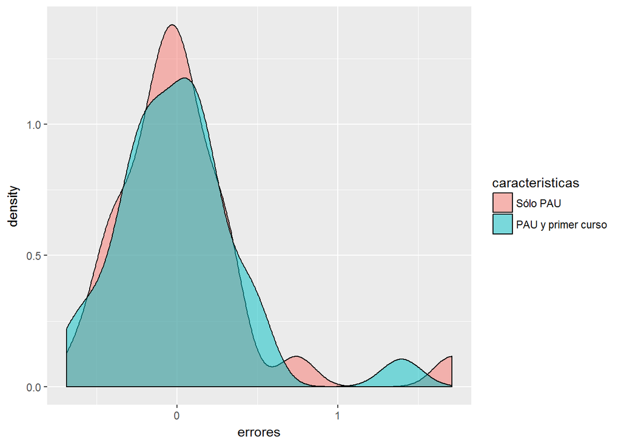

```r
### Completar aquí, usando ggplot con geom_density
plot <- errores  %>%
        ggplot(aes(x = errores))
plot + geom_density(aes(fill = caracteristicas), alpha = 0.5)
```

Finalmente, vamos a obtener los tres indicadores numéricos de la calidad de la predicción, al igual que para el ajuste anterior. Lo hacemos reutilizando el bloque “chunk” que ya programamos, sin necesidad de copiar y pegar, usando la opción ref.label:

```r
## Completar aquí para obtener resumenerrores
resumenerrores <- errores %>%
                  group_by(caracteristicas) %>%
                  summarise(error_cuadratico = mean(errores^2, na.rm = TRUE), ##1
                         p0.25 = sum(abs(errores) < 0.25, na.rm =
                                       TRUE) / length(errores) * 100, ##2
                         p0.1 = sum(abs(errores) < 0.1, na.rm =
                                      TRUE) / length(errores) * 100) ##3
```

## Predicción con todas las características disponibles en el conjunto

Vamos ahora a usar todas las características disponibles en el conjunto de datos.

Seguiremos los mismos pasos que para los ajustes anteriores

### Ajuste con lm

Crear un objeto **training.lm.completo** que sea el resultado de llevar a cabo, con el conjunto GradosTeleco.training el ajuste lineal para predecir la nota media en función de todas las características. (podréis usar el hecho de que para incluir todas las variables en una fórmula de lm, podemos usar el punto . )

```r
## Completar aquí para obtener training.lm.completo
training.lm.completo <- lm(data = GradosTeleco.training, notamedia ~ PAU_CALIFICACION_NOTA_MATERIA + PAU_CALIFICACION_NOTA_MATERIA_DECIL + FISICA_NOTA_MATERIA + FISICA_NOTA_MATERIA_DECIL + MATEMATICAS_II_NOTA_MATERIA + MATEMATICAS_II_NOTA_MATERIA_DECIL + FUNDAMENTOS_DE_PROGRAMACION_NOTA + FUNDAMENTOS_DE_PROGRAMACION_CONVOCS_PRESENTADAS_ACUMULA + FUNDAMENTOS_DE_PROGRAMACION_CONVOCS_HASTA_1RA_VEZ_ACUMULA + SISTEMAS_Y_CIRCUITOS_NOTA + SISTEMAS_Y_CIRCUITOS_CONVOCS_PRESENTADAS_ACUMULA + SISTEMAS_Y_CIRCUITOS_CONVOCS_HASTA_1RA_VEZ_ACUMULA + TEORIA_DE_LA_COMUNICACION_NOTA + TEORIA_DE_LA_COMUNICACION_CONVOCS_PRESENTADAS_ACUMULA + TEORIA_DE_LA_COMUNICACION_CONVOCS_HASTA_1RA_VEZ_ACUMULA)

##Variable = notamedia
##Característica = asignaturas de la carrera
##he tomado los valores de las notas de la PAU + las notas de las asignaturas de la carrera que me proporcionan una nota media, para lo que he añadido ahora las variables de la asignatura T.Comunicacion
```

### Predicción de la nota media para el conjunto test

Crear un objeto llamado test.predict.completo, que contenga el resultado de las predicciones para los individuos del conjunto de test, usando el ajuste de training.lm.completo

```r
## Completar aquí par crear test.predict.PAU.primeros cursos
test.predict.completo <- predict(training.lm.completo, GradosTeleco.test)
##ajuste = training.lm.completo
##individuos del conjunto test = GradosTeleco.test
```

### Comprobación de la calidad de la predicción para el conjunto test.

Cremos ahora el vector errores.predict.completo que contenga los errores que hemos cometido en la predicción de las notas medias para el conjunto test, si usamos el nuevo ajuste.

```r
## Completar aquí para obtener el vector errores.predict.completo
errores.predict.completo <- GradosTeleco.test$notamedia - test.predict.completo
```

Vamos ahora a añadir estos errores al dataframe errores que ya contenía los errores para el ajuste con solamente las características PAU.

```r
### Completar aquí
errores <- rbind(errores,
                 data.frame(caracteristicas = "completo",
                            errores = errores.predict.completo))
```

Realizamos ahora una gráfica de densidad para visualizar la distribución de los errores cometidos en la predicción, pero distinguiendo entre los tres ajustes

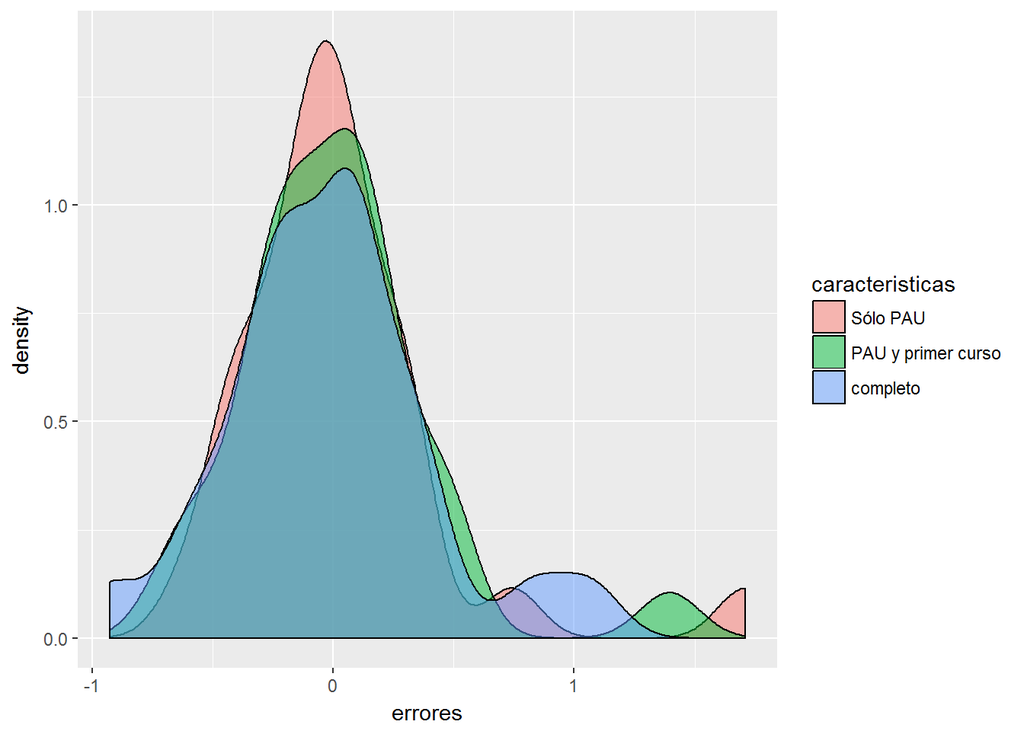

```r
### Completar aquí, usando ggplot con geom_density
plot <- errores  %>%
        ggplot(aes(x = errores))

plot + geom_density(aes(fill = caracteristicas), alpha = 0.5)
```

Finalmente, vamos a obtener los tres indicadores numéricos de la calidad de la predicción, al igual que para el ajuste anterior.

```r
## Completar aquí para obtener resumenerrores
resumenerrores <- errores %>%
                  group_by(caracteristicas) %>%
                  summarise(error_cuadratico = mean(errores^2, na.rm = TRUE), ##1
                         p0.25 = sum(abs(errores) < 0.25, na.rm =
                                       TRUE) / length(errores) * 100, ##2
                         p0.1 = sum(abs(errores) < 0.1, na.rm =
                                      TRUE) / length(errores) * 100) ##3
```

## Comparación de los tres ajustes

En la tabla siguiente, recogemos la calidad de predicción obtenida con los tres ajustes:

```r
## nada que completar aquí
library("xtable")
print(xtable(resumenerrores), type = "html", include.rownames =FALSE)
```

| caracteristicas | error_cuadratico | p0.25 | p0.1 |
| --- | --- | --- | --- |
| Sólo PAU | 0.18 | 60.00 | 30.00 |
| PAU y primer curso | 0.15 | 60.00 | 23.33 |
| completo | 0.17 | 46.67 | 23.33 |

Para visualizar nuestra predicción, usando el ajuste completo, sobre el conjunto test, vamos a representar una nube de puntos de la nota media en función de la calificación obtenida en la PAU, PAU_CALIFICACION_NOTA_MATERIA, y añadiremos puntos rojos que corresponden a nuestra predicción de cada nota media usando el modelo completo.

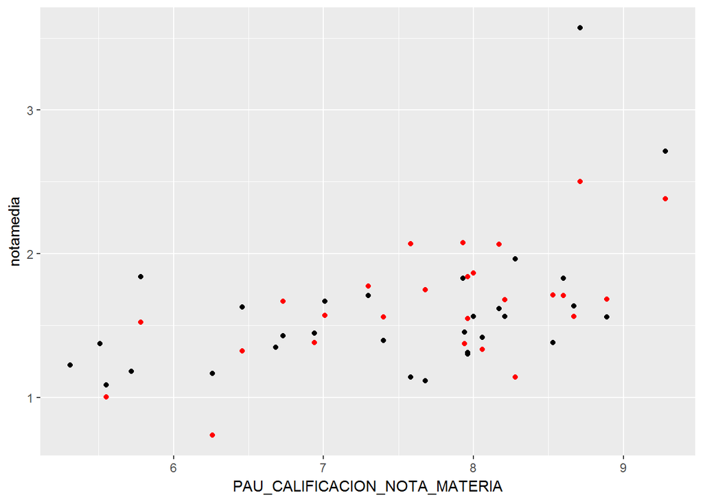

```r
## Completar aquí, con la representación de notamedia
## en función de PAU_CALIFICACION_NOTA_MATERIA
plot <- GradosTeleco.test  %>%
        mutate(prediccion = test.predict.completo) %>%
        ggplot(aes(x = PAU_CALIFICACION_NOTA_MATERIA, y = notamedia)) + geom_point() +
        geom_point(aes(y = test.predict.completo), colour = "red")
plot
```